# prgramming06

Xueyuan Li

2022-10-13

##Which quantiles of a continuous distribution can one estimate with more precision?

### Introduction

The median is an important quantity in data analysis. It represents the middle value of the data distribution. Estimates of the median, however, have a degree of uncertainty because (a) the estimates are calculated from a finite sample and (b) the data distribution of the underlying data is generally unknown. One important roles of a data scientist is to quantify and to communicate the degree of uncertainty in his or her data analysis.

In this blog, I will answer a series of questions related to the variation of the median (and a range of other quantiles) and I will also use some analytic methods to answer these questions.

### Questions & Solution

#### Q1: Begin with the median from a sample of N = 200 from the standard normal distribution. Write an R function that is the density function for the median in this sample. Note that the 100th order statistic is approximately the median, and use the order statistic formula discussed in class. Generate a plot of the function.

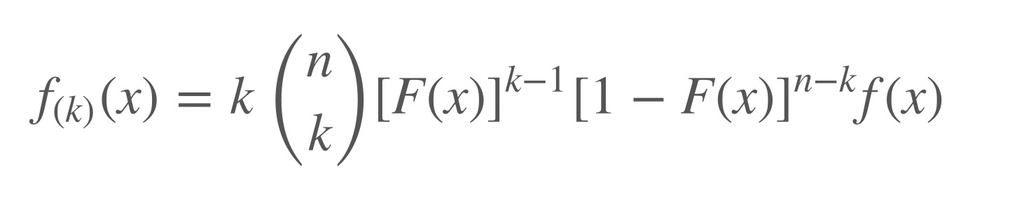

the distribution of X(k)

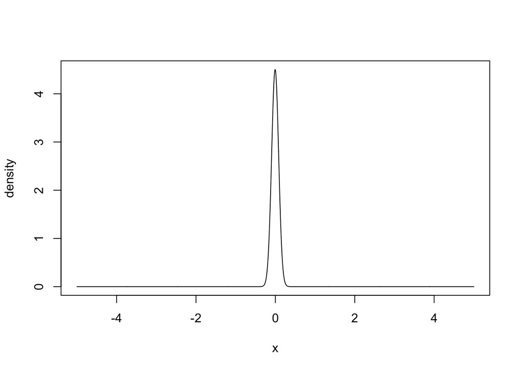

```r
dorder= function(x,n,k){
  k*choose(n,k)*
    (pnorm(x))^(k-1)*
    (1-pnorm(x))^(n-k)*
    dnorm(x)
}
x=seq(-5,5,by=0.01)

density=dorder(x,n=200,k=100)
plot(x,density,type="l")
```

for the normal distribution , the mean and the median are about the same, both close to 0.

#### Q2: Write an R function that is the probability function for the median in this sample. Use the order statistic formula discussed in class. Generate a plot of the function.

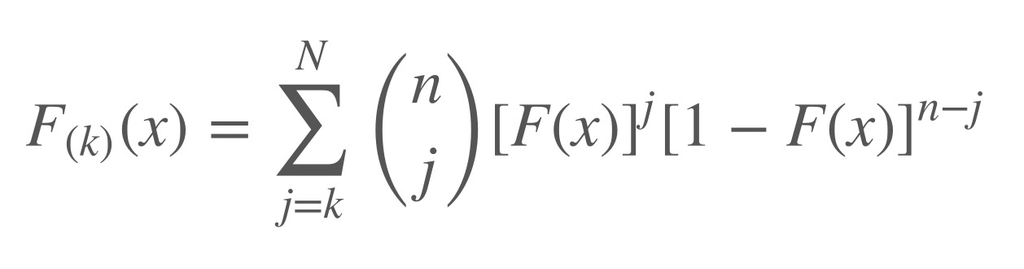

the distribution of X(k)

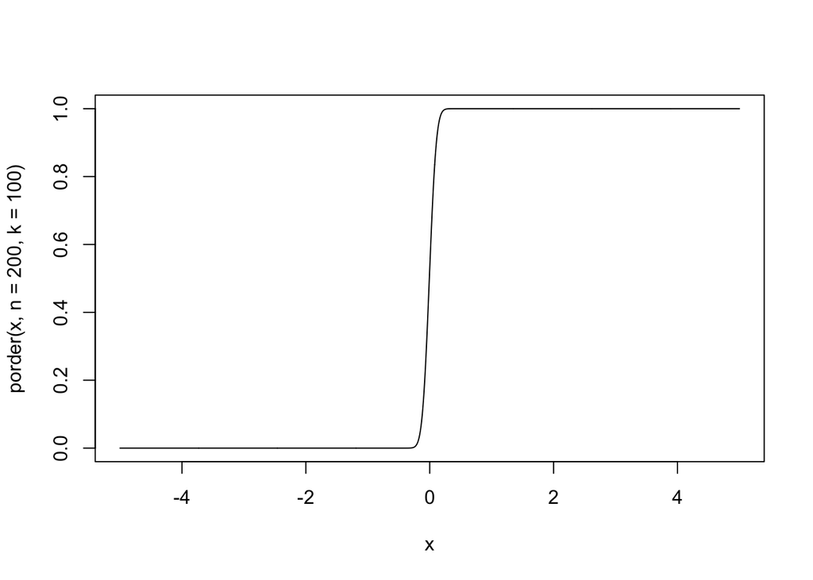

```r
porder= function(x,n,k){
  pbinom(k-1,n,pnorm(x),lower.tail=FALSE)

  #for example
  #pbinom(5,2,.3)=dbinom(5,0,.3)+dbinom(5,1,.3)+dbinom(5,2,.3)
  #pbinom(5,2,.3,lower.tail=FALSE)=dbinom(5,3,.3)+dbinom(5,4,.3)+dbinom(5,5,.3)
}
x=seq(-5,5,by=0.01)
plot(x,porder(x,n=200,k=100),type ="l")
```

#### Q3: Write an R function that is the quantile function for the median in this sample. (You have several options for how to write this function.) Generate a plot of the function.-CDF

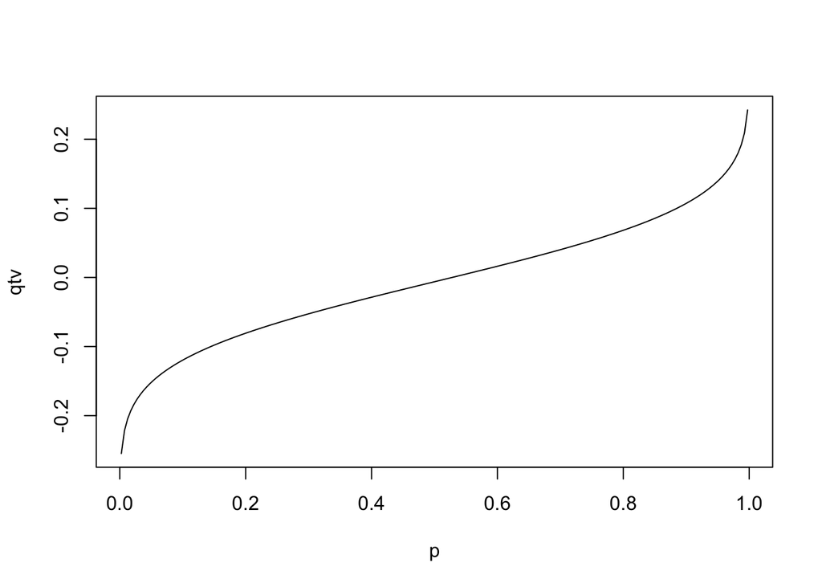

```r
p=ppoints(200) #between 0 and 1

qorder=function(p,n,k){
  out=p
  for(i in seq_along(p)){
    #The function uniroot searches the interval from lower to upper for a root (i.e., zero) of the function f with respect to its first argument.
    out[i]=uniroot(function(x) {porder(x,n,k)-p[i]},c(-100,100))$root

  }
out
}
qtv=qorder(p,n=200,k=100)
plot(p,qtv,type="l")
```

#### Q4:Simulate the sampling distribution for the median. Create a plot of the empirical CDF (ECDF).Overlay the plot of the ECDF with a plot of the CDF.

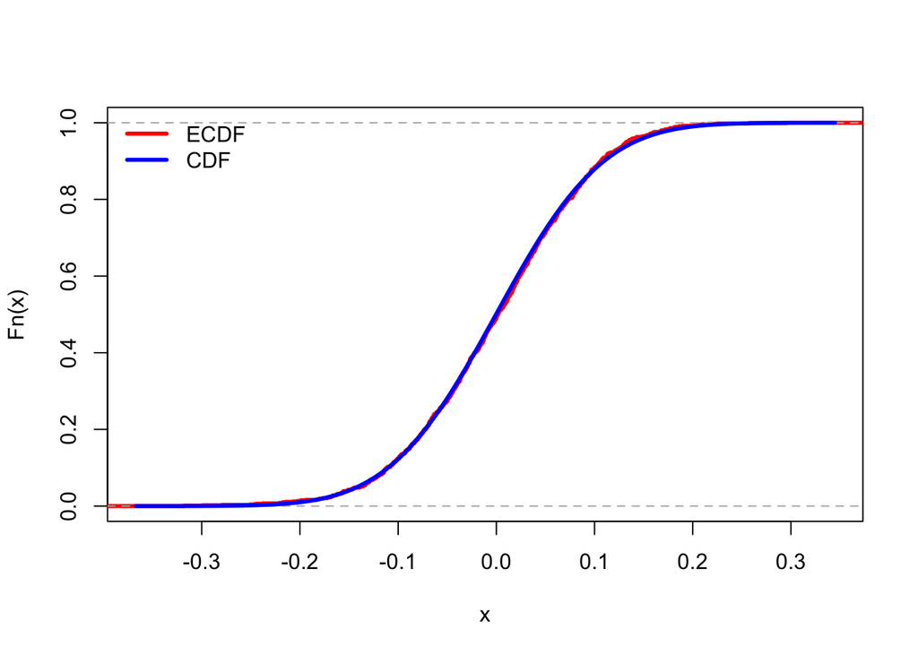

```r
#first step: need to sample rnorm(200) and compute median
temp=rnorm(200)
med1=median(temp) #close to 0
#second step: repeat this  1000 times
median_values=NA
for(i in 1:1000){
  temp=rnorm(200)
  median_values[i]=median(temp)
}
# third step: you have 1000 median values, then use ecdf(), then plot(ecdf())
plot(ecdf(median_values),main="",lwd=3,col="red")
#curve(theoretical cdf from standard normal)
curve(pnorm(x,mean(median_values),sd(median_values)),add=TRUE,lwd=3,col="blue")
legend(
"topleft"
, c("ECDF","CDF") ,lwd=3
, col = c("red","blue") ,bty="n"
)
```

#### Q5: Using the simulated sampling distribution from the previous question, create a histogram (on the density scale). Overlay the histogram with a plot of the density function.

```r
library(tidyverse)
```

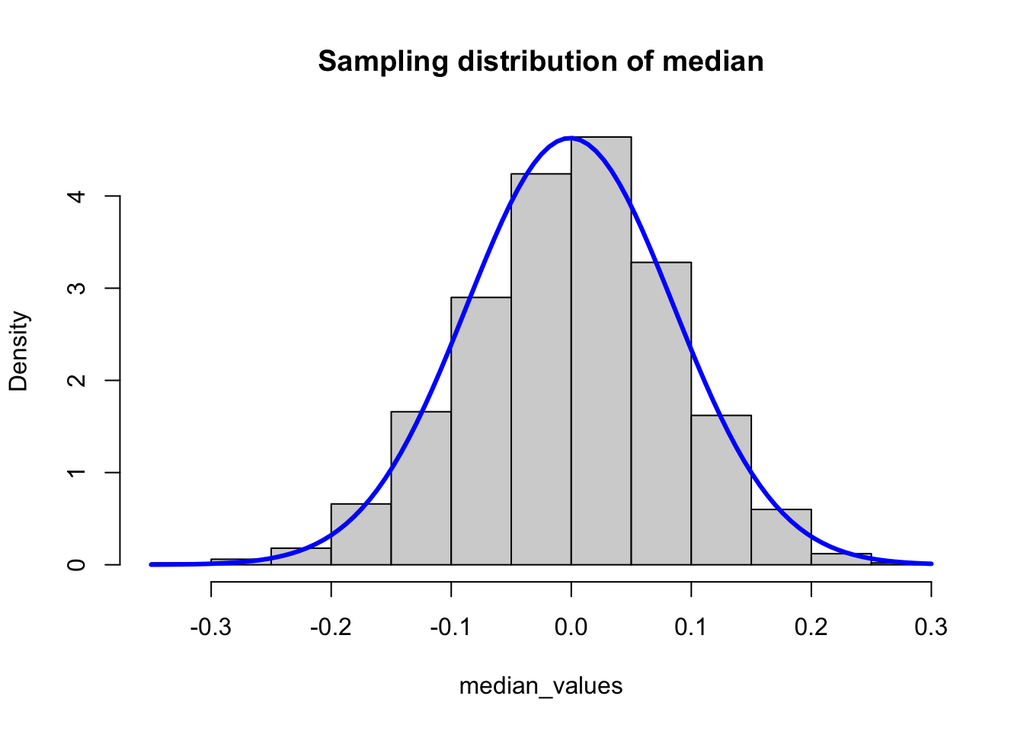

```r
#first step: need to sample rnorm(200) and compute median
temp=rnorm(200)
med1=median(temp) #close to 0

#second step: repeat this  1000 times
for(i in 1:100){
  temp=rnorm(200)
  median_values[i]=median(temp)
}


# third step: you have 1000 median values
hist(median_values,main="Sampling distribution of median",freq=FALSE)
#curve(add theoretical pdf for median of standard normal)
curve(dnorm(x,mean(median_values),sd(median_values)),add=TRUE,lwd=3,col="blue")
```

#### Q6: One very common way to compare a random sample to a theoretical candidate distribution is the QQ plot. It is created by ploting quantiles of the theoretical distribution on the x-axis and empirical quantiles from the sample on the y-axis.

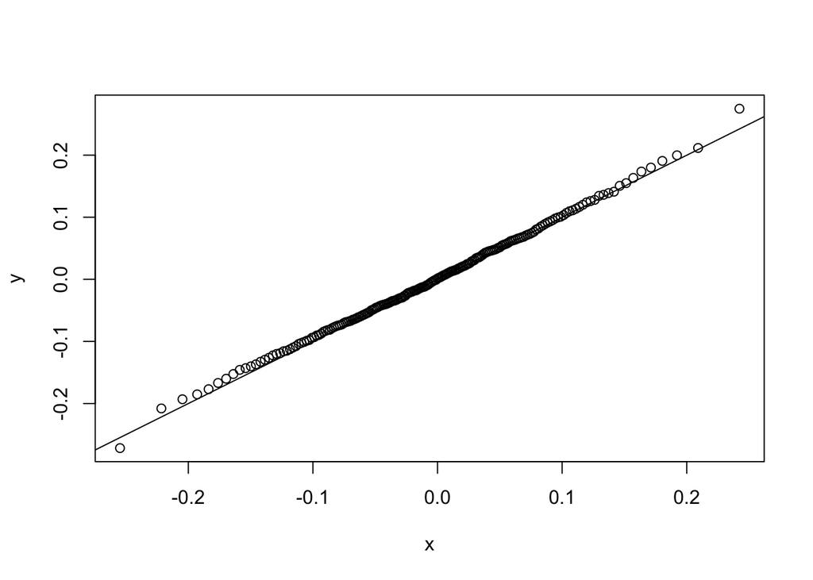

```r
medians=NA

for(k in 1:1000){
  temp=rnorm(200)
  medians[k]=median(temp) #get 1000 median values
}

p=ppoints(200)

x=qorder(p,n=200,k=100)  #use the function from Q3
y=quantile(medians,probs=p)

plot(x,y)
abline(c(0,1))  #reference line
```

The two lines are close means: empirical distribution(ecdf) is very close to theoretical distribution

#### Q7: Modify the dorder , porder , and qorder functions so that the functions take a new parameter k (for the k-th order statistic) so that the functions will work for any order statistic and not just the median.

```r
library(magrittr)
```

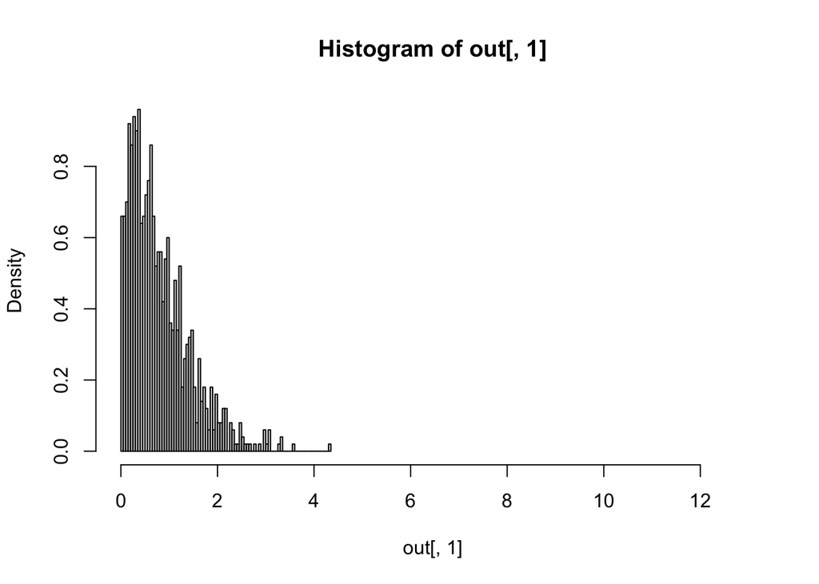

```r
fk <- function(x,k,n,dist="norm",...){
  F <- eval(parse(text="p" %|% dist))
  f <- eval(parse(text="d" %|% dist))
  k*
    choose(n,k)*
    (F(x, ...))^(k-1)*
    (1-F(x, ...))^(n-k)*
    f(x, ...)
}

out <- replicate(
  1000
  , {
    ft1 <- rweibull(3,shape=1.3,scale=2)
    c(ft1 %>% min, ft1 %>% max)
  }) %>%
  t

hist(out[,1],freq=FALSE,breaks=100, xlim=c(0,max(out)))
```

```r
#curve(fk(x,mean(x),sd(x),dist="weibull",shape=1.3, scale=2),add=TRUE,lwd=5,col="red")
```

#### Q8: Generate the QQ plot for simulated data from the sampling distribution of the sample max and the theoretical largest order statistic distribution.

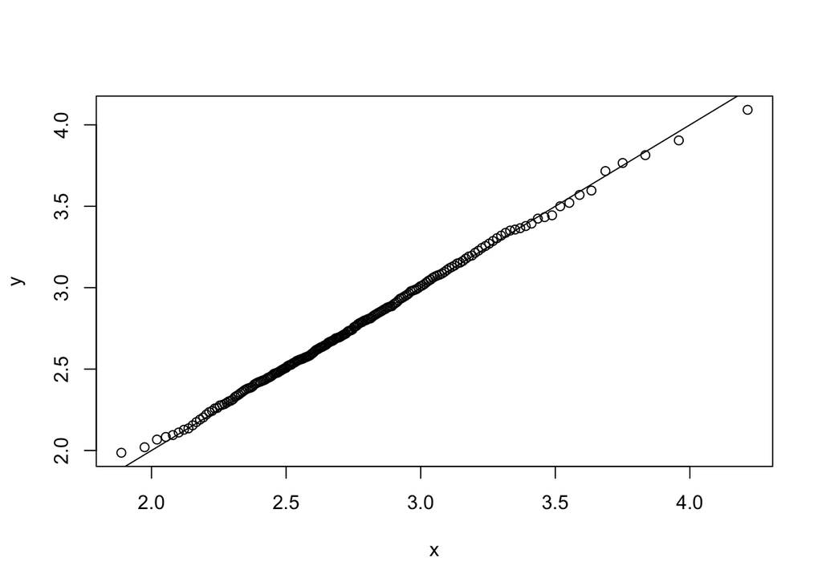

```r
maxs=NA

for(k in 1:1000){
  temp=rnorm(200)
  maxs[k]=max(temp) #get 1000 median values
}

p=ppoints(200)

x=qorder(p,n=200,k=200)  #use the function from Q3 , change k =max=200
y=quantile(maxs,probs=p)

plot(x,y)
abline(c(0,1))  #reference line
```